# QTL

### Start codon from gencode annotation

cat gencode.v19.annotation.gtf | grep “start_codon” > a.gtf  
#Extract columns for chromosome, start codon position, gene id, and strand direction  
awk -vOFS=“ ’{sub(/.*“/,”“,$9);print $1, $4, $5, $05, $8, $7}’ a.gtf > a.bed  
#Remove gene versions  
awk ‘{gsub(/"|;/,““,$4)}1’ a.bed > gencode.v19.start.codons.bed  
rm a.bed  
rm a.gtf

### teQTL FDR<0.1

#teQTL genes

#Get teQTL gene ids  
awk ‘$5 <= 0.10’ cis.teQTL.mapping.permutation.pass.results.table > teqtl.fdr10.table  
cat teqtl.fdr10.table | awk ‘{print $1}’ > teqtl.fdr10.names  
#Extract teQTL genes  
grep -f teqtl.fdr10.names gencode.v19.start.codons.bed > teqtl.fdr10.selected.bed  
awk ’{sub(/..*/,““,$4)} 1’ teqtl.fdr10.selected.bed > teqtl.fdr10.selected.start.codons.bed

```r
setwd('~/Documents/QTL')
teqtl10bed = read.table('teqtl.fdr10.selected.start.codons.bed')
colnames(teqtl10bed) <- c('chrom', 'chromStart', 'chromEnd', 'name', 'score', 'strand')
#Designate Kozak region as -9 to +6 of start codon
#9 before start position to 6 after start position if strand is +; 6 before start position to 9 after start position if strand is -
teqtl10bed$chromStart <- ifelse(teqtl10bed$strand == '+', teqtl10bed$chromStart - 9, teqtl10bed$chromStart - 6)
teqtl10bed$chromEnd <- ifelse(teqtl10bed$strand == '+', teqtl10bed$chromEnd + 6, teqtl10bed$chromEnd + 9)
#Remove chr from chromosome number column
teqtl10bed$chrom <- gsub('^chr', '', teqtl10bed$chrom)
write.table(teqtl10bed, 'teqtl.fdr10.kozak.bed', quote = FALSE, row.names = FALSE, col.names =  FALSE, sep ='\t')
```

#Non-teQTL genes

#Get non-teQTL gene ids  
awk ‘$5 >0.10’ cis.teQTL.mapping.permutation.pass.results.table | awk ‘NR>1’ > non.teqtl.fdr10.table  
cat non.teqtl.fdr10.table | awk ‘{print $1}’ > non.teqtl.fdr10.names  
#Extract non-teQTL gene ids  
grep -f non.teqtl.fdr10.names gencode.v19.start.codons.bed > non.teqtl.fdr10.selected.bed  
awk ’{sub(/..*/,““,$4)} 1’ non.teqtl.fdr10.selected.bed > non.teqtl.fdr10.selected.start.codons.bed

```r
setwd('~/Documents/QTL')
nonteqtl10bed = read.table('non.teqtl.fdr10.selected.start.codons.bed')
colnames(nonteqtl10bed) <- c('chrom', 'chromStart', 'chromEnd', 'name', 'score', 'strand')
#Designate Kozak region as -9 to +6 of start codon
#9 before start position to 6 after start position if strand is +; 6 before start position to 9 after start position if strand is -
nonteqtl10bed$chromStart <- ifelse(nonteqtl10bed$strand == '+', nonteqtl10bed$chromStart - 9, nonteqtl10bed$chromStart - 6)
nonteqtl10bed$chromEnd <- ifelse(nonteqtl10bed$strand == '+', nonteqtl10bed$chromEnd + 6, nonteqtl10bed$chromEnd + 9)
#Remove chr from chromosome number column
nonteqtl10bed$chrom <- gsub('^chr', '', nonteqtl10bed$chrom)
write.table(nonteqtl10bed, 'non.teqtl.fdr10.kozak.bed', quote = FALSE, row.names = FALSE, col.names =  FALSE, sep ='\t')
```

#Clean up duplicates  
cat teqtl.fdr10.kozak.bed | uniq > teqtl.fdr10.kozak.uniq.bed  
cat non.teqtl.fdr10.kozak.bed | uniq > non.teqtl.fdr10.kozak.uniq.bed

#Intersect SNPs with Kozak regions  
bedtools intersect -a psychENCODE.mergedGenotype.RRP.190sample.commonSet.vcf.gz -b teqtl.fdr10.kozak.uniq.bed -wa -wb | bgzip > results.teqtl.fdr10.nohead.vcf.gz  
bedtools intersect -a psychENCODE.mergedGenotype.RRP.190sample.commonSet.vcf.gz -b non.teqtl.fdr10.kozak.uniq.bed -wa -wb | bgzip > results.nonteqtl.fdr10.nohead.vcf.gz

#Create contingency table of genes and SNPs for teQTL and non-teQTL genes  
echo Genes > results.fdr10  
wc -l < non.teqtl.fdr10.names >> results.fdr10  
wc -l < teqtl.fdr10.names >> results.fdr10  
echo SNPs >> results.fdr10  
zcat results.nonteqtl.fdr10.nohead.vcf.gz | wc -l >> results.fdr10  
zcat results.teqtl.fdr10.nohead.vcf.gz | wc -l >> results.fdr10

paste - - - < results.fdr10 > results.fdr10.tab

```r
setwd('~/Documents/QTL')
results.fdr10 <- read.table('results.fdr10.tab')
#Name rows and columns of contingency table
rownames(results.fdr10) <- results.fdr10[,1]
results.fdr10 <- results.fdr10[,-1]
names(results.fdr10) <- c('Non-teQTL', 'teQTL')
#Fisher's exact test
fisher.test(results.fdr10)
#Mosaic plot of contingency table
mosaicplot(results.fdr10, col = c('lightblue','pink'), main = 'FDR <= 0.10')
pdf(file = '~/Documents/QTL/mosaic.fdr10.pdf', width = 5, height = 4)
mosaicplot(results.fdr10, col = c('lightblue','pink'), main = 'FDR <= 0.10')
dev.off()
```

#Get chromosome, SNP location, Kozak position, gene id, strand direction from intersection results  
zcat results.teqtl.fdr10.nohead.vcf.gz | awk ‘{print $1, $2, $(NF-4), $(NF-3), $(NF-2), $NF}’ > results.teqtl.fdr10.table  
zcat results.nonteqtl.fdr10.nohead.vcf.gz | awk ‘{print $1, $2, $(NF-4), $(NF-3), $(NF-2), $NF}’ > results.nonteqtl.fdr10.table

```r
library(ggplot2)
setwd('~/Documents/QTL')
#FDR <0.10
teqtl10.results <- read.table('results.teqtl.fdr10.table')
nonteqtl10.results <- read.table('results.nonteqtl.fdr10.table')
#Name columns
names(teqtl10.results) <- c('Chrom','SNP','KStart','KEnd','Gene','Strand')
names(nonteqtl10.results) <- c('Chrom','SNP','KStart','KEnd','Gene','Strand')
#Designate start codon position
teqtl10.results$Start <- ifelse(teqtl10.results$Strand == '+', teqtl10.results$KStart + 9, teqtl10.results$KStart + 6)
#Find position of SNP relative to start codon; 3 bases of start codon itself is designated as 0
teqtl10.results$Pos <- ifelse(teqtl10.results$Strand == '+', teqtl10.results$SNP - teqtl10.results$Start, teqtl10.results$Start - teqtl10.results$SNP)
#To account for all 3 bases of start codon, subtract 2 if position is positive for positive strands and add 2 if negative for negative strands
teqtl10.results$Pos <- ifelse(teqtl10.results$Strand == '+', ifelse(teqtl10.results$Pos > 0, teqtl10.results$Pos - 2, teqtl10.results$Pos), ifelse(teqtl10.results$Pos < 0, teqtl10.results$Pos + 2, teqtl10.results$Pos))
#Designate start codon position
nonteqtl10.results$Start <- ifelse(nonteqtl10.results$Strand == '+', nonteqtl10.results$KStart + 9, nonteqtl10.results$KStart + 6)
#Find position of SNP relative to start codon; 3 bases of start codon itself is designated as 0
nonteqtl10.results$Pos <- ifelse(nonteqtl10.results$Strand == '+', nonteqtl10.results$SNP - nonteqtl10.results$Start, nonteqtl10.results$Start - nonteqtl10.results$SNP)
#To account for all 3 bases of start codon, subtract 2 if position is positive for positive strands and add 2 if negative for negative strands
nonteqtl10.results$Pos <- ifelse(nonteqtl10.results$Strand == '+', ifelse(nonteqtl10.results$Pos > 0, nonteqtl10.results$Pos - 2, nonteqtl10.results$Pos), ifelse(nonteqtl10.results$Pos < 0, nonteqtl10.results$Pos + 2, nonteqtl10.results$Pos))
#Plot histograms
ggplot(teqtl10.results, aes(x=Pos)) + geom_histogram(fill = 'pink', color = 'black', bins = 16, binwidth = 1) + scale_y_continuous(limits = c(0,15.5), expand = c(0,0)) + scale_x_continuous(breaks=-9:6) + theme_classic() + ylab('Counts') + xlab('Position Relative to Start Codon') + ggtitle('teQTL SNPs FDR<0.10')
ggplot(nonteqtl10.results, aes(x=Pos)) + geom_histogram(fill = 'light blue', color = 'black', bins = 16, binwidth = 1) + scale_y_continuous(limits = c(0,50), expand = c(0,0)) + scale_x_continuous(breaks=-9:6) + theme_classic() + ylab('Counts') + xlab('Position Relative to Start Codon') + ggtitle('Non-teQTL SNPs FDR<0.10')
pdf(file = '~/Documents/QTL/histogram.teqtl.fdr10.results.pdf', width = 10, height = 5)
ggplot(teqtl10.results, aes(x=Pos)) + geom_histogram(fill = 'pink', color = 'black', bins = 16, binwidth = 1) + scale_y_continuous(limits = c(0,15.5), expand = c(0,0)) + scale_x_continuous(breaks=-9:6) + theme_classic() + theme(plot.title = element_text(size = 24)) + ylab('Counts') + xlab('Position Relative to Start Codon') + ggtitle('teQTL SNPs FDR<0.10')
dev.off()
pdf(file = '~/Documents/QTL/histogram.nonteqtl.fdr10.results.pdf', width = 10, height = 5)
ggplot(nonteqtl10.results, aes(x=Pos)) + geom_histogram(fill = 'light blue', color = 'black', bins = 16, binwidth = 1) + scale_y_continuous(limits = c(0,50), expand = c(0,0)) + scale_x_continuous(breaks=-9:6) + theme_classic() + theme(plot.title = element_text(size = 24)) + ylab('Counts') + xlab('Position Relative to Start Codon') + ggtitle('Non-teQTL SNPs FDR<0.10')
dev.off()
```

### teQTL FDR<0.05

#teQTL genes

#Get teQTL gene ids awk ‘$5 <= 0.05’ cis.teQTL.mapping.permutation.pass.results.table > teqtl.fdr05.table  
cat teqtl.fdr05.table | awk ‘{print $1}’ > teqtl.fdr05.names  
#Extract teQTL genes  
grep -f teqtl.fdr05.names gencode.v19.start.codons.bed > teqtl.fdr05.selected.bed  
awk ’{sub(/..*/,““,$4)} 1’ teqtl.fdr05.selected.bed > teqtl.fdr05.selected.start.codons.bed

```r
setwd('~/Documents/QTL')
teqtl05bed = read.table('teqtl.fdr05.selected.start.codons.bed')
colnames(teqtl05bed) <- c('chrom', 'chromStart', 'chromEnd', 'name', 'score', 'strand')
#Designate Kozak region as -9 to +6 of start codon
#9 before start position to 6 after start position if strand is +; 6 before start position to 9 after start position if strand is -
teqtl05bed$chromStart <- ifelse(teqtl05bed$strand == '+', teqtl05bed$chromStart - 9, teqtl05bed$chromStart - 6)
teqtl05bed$chromEnd <- ifelse(teqtl05bed$strand == '+', teqtl05bed$chromEnd + 6, teqtl05bed$chromEnd + 9)
#Remove chr from chromosome number column
teqtl05bed$chrom <- gsub('^chr', '', teqtl05bed$chrom)
write.table(teqtl05bed, 'teqtl.fdr05.kozak.bed', quote = FALSE, row.names = FALSE, col.names =  FALSE, sep ='\t')
```

#Non-teQTL genes

#Get non-teQTL gene ids  
awk ‘$5 >0.05’ cis.teQTL.mapping.permutation.pass.results.table | awk ‘NR>1’ > non.teqtl.fdr05.table  
cat non.teqtl.fdr05.table | awk ‘{print $1}’ > non.teqtl.fdr05.names  
#Extract non-teQTL gene ids  
grep -f non.teqtl.fdr05.names gencode.v19.start.codons.bed > non.teqtl.fdr05.selected.bed  
awk ’{sub(/..*/,““,$4)} 1’ non.teqtl.fdr05.selected.bed > non.teqtl.fdr05.selected.start.codons.bed

```r
setwd('~/Documents/QTL')
nonteqtl05bed = read.table('non.teqtl.fdr05.selected.start.codons.bed')
colnames(nonteqtl05bed) <- c('chrom', 'chromStart', 'chromEnd', 'name', 'score', 'strand')
#Designate Kozak region as -9 to +6 of start codon
#9 before start position to 6 after start position if strand is +; 6 before start position to 9 after start position if strand is -
nonteqtl05bed$chromStart <- ifelse(nonteqtl05bed$strand == '+', nonteqtl05bed$chromStart - 9, nonteqtl05bed$chromStart - 6)
nonteqtl05bed$chromEnd <- ifelse(nonteqtl05bed$strand == '+', nonteqtl05bed$chromEnd + 6, nonteqtl05bed$chromEnd + 9)
#Remove chr from chromosome number column
nonteqtl05bed$chrom <- gsub('^chr', '', nonteqtl05bed$chrom)
write.table(nonteqtl05bed, 'non.teqtl.fdr05.kozak.bed', quote = FALSE, row.names = FALSE, col.names =  FALSE, sep ='\t')
```

#Clean up duplicates  
cat teqtl.fdr05.kozak.bed | uniq > teqtl.fdr05.kozak.uniq.bed  
cat non.teqtl.fdr05.kozak.bed | uniq > non.teqtl.fdr05.kozak.uniq.bed

#Intersect SNPs with Kozak regions  
bedtools intersect -a psychENCODE.mergedGenotype.RRP.190sample.commonSet.vcf.gz -b teqtl.fdr05.kozak.uniq.bed -wa -wb | bgzip > results.teqtl.fdr05.nohead.vcf.gz  
bedtools intersect -a psychENCODE.mergedGenotype.RRP.190sample.commonSet.vcf.gz -b non.teqtl.fdr05.kozak.uniq.bed -wa -wb | bgzip > results.nonteqtl.fdr05.nohead.vcf.gz

#Create contingency table of genes and SNPs for teQTL and non-teQTL genes  
echo Genes > results.fdr05  
wc -l < non.teqtl.fdr05.names >> results.fdr05  
wc -l < teqtl.fdr05.names >> results.fdr05  
echo SNPs >> results.fdr05  
zcat results.nonteqtl.fdr05.nohead.vcf.gz | wc -l >> results.fdr05  
zcat results.teqtl.fdr05.nohead.vcf.gz | wc -l >> results.fdr05

paste - - - < results.fdr05 > results.fdr05.tab

```r
setwd('~/Documents/QTL')
results.fdr05 <- read.table('results.fdr05.tab')
#Name rows and columns of contingency table
rownames(results.fdr05) <- results.fdr05[,1]
results.fdr05 <- results.fdr05[,-1]
names(results.fdr05) <- c('Non-teQTL', 'teQTL')
#Fisher's exact test
fisher.test(results.fdr05)
#Mosaic plot of contingency table
mosaicplot(results.fdr05, col = c('lightblue','pink'), main = 'FDR <= 0.05')
pdf(file = '~/Documents/QTL/mosaic.fdr05.pdf', width = 5, height = 4)
mosaicplot(results.fdr05, col = c('lightblue','pink'), main = 'FDR <= 0.05')
dev.off()
```

#Get chromosome, SNP location, Kozak position, gene id, strand direction from intersection results  
zcat results.teqtl.fdr05.nohead.vcf.gz | awk ‘{print $1, $2, $(NF-4), $(NF-3), $(NF-2), $NF}’ > results.teqtl.fdr05.table  
zcat results.nonteqtl.fdr05.nohead.vcf.gz | awk ‘{print $1, $2, $(NF-4), $(NF-3), $(NF-2), $NF}’ > results.nonteqtl.fdr05.table

```r
library(ggplot2)
setwd('~/Documents/QTL')
#FDR <0.05
teqtl05.results <- read.table('results.teqtl.fdr05.table')
nonteqtl05.results <- read.table('results.nonteqtl.fdr05.table')
#Name columns
names(teqtl05.results) <- c('Chrom','SNP','KStart','KEnd','Gene','Strand')
names(nonteqtl05.results) <- c('Chrom','SNP','KStart','KEnd','Gene','Strand')
#Designate start codon position
teqtl05.results$Start <- ifelse(teqtl05.results$Strand == '+', teqtl05.results$KStart + 9, teqtl05.results$KStart + 6)
#Find position of SNP relative to start codon; 3 bases of start codon itself is designated as 0
teqtl05.results$Pos <- ifelse(teqtl05.results$Strand == '+', teqtl05.results$SNP - teqtl05.results$Start, teqtl05.results$Start - teqtl05.results$SNP)
#To account for all 3 bases of start codon, subtract 2 if position is positive for positive strands and add 2 if negative for negative strands
teqtl05.results$Pos <- ifelse(teqtl05.results$Strand == '+', ifelse(teqtl05.results$Pos > 0, teqtl05.results$Pos - 2, teqtl05.results$Pos), ifelse(teqtl05.results$Pos < 0, teqtl05.results$Pos + 2, teqtl05.results$Pos))
#Designate start codon position
nonteqtl05.results$Start <- ifelse(nonteqtl05.results$Strand == '+', nonteqtl05.results$KStart + 9, nonteqtl05.results$KStart + 6)
#Find position of SNP relative to start codon; 3 bases of start codon itself is designated as 0
nonteqtl05.results$Pos <- ifelse(nonteqtl05.results$Strand == '+', nonteqtl05.results$SNP - nonteqtl05.results$Start, nonteqtl05.results$Start - nonteqtl05.results$SNP)
#To account for all 3 bases of start codon, subtract 2 if position is positive for positive strands and add 2 if negative for negative strands
nonteqtl05.results$Pos <- ifelse(nonteqtl05.results$Strand == '+', ifelse(nonteqtl05.results$Pos > 0, nonteqtl05.results$Pos - 2, nonteqtl05.results$Pos), ifelse(nonteqtl05.results$Pos < 0, nonteqtl05.results$Pos + 2, nonteqtl05.results$Pos))
#Plot histograms
ggplot(teqtl05.results, aes(x=Pos)) + geom_histogram(fill = 'pink', color = 'black', bins = 16, binwidth = 1) + scale_y_continuous(limits = c(0,12), expand = c(0,0)) + scale_x_continuous(breaks=-9:6) + theme_classic() + ylab('Counts') + xlab('Position Relative to Start Codon') + ggtitle('teQTL SNPs FDR<0.05')
ggplot(nonteqtl05.results, aes(x=Pos)) + geom_histogram(fill = 'light blue', color = 'black', bins = 16, binwidth = 1) + scale_y_continuous(limits = c(0,50), expand = c(0,0)) + scale_x_continuous(breaks=-9:6) + theme_classic() + ylab('Counts') + xlab('Position Relative to Start Codon') + ggtitle('Non-teQTL SNPs FDR<0.05')
pdf(file = '~/Documents/QTL/histogram.teqtl.fdr05.results.pdf', width = 10, height = 5)
ggplot(teqtl05.results, aes(x=Pos)) + geom_histogram(fill = 'pink', color = 'black', bins = 16, binwidth = 1) + scale_y_continuous(limits = c(0,12), expand = c(0,0)) + scale_x_continuous(breaks=-9:6) + theme_classic() + theme(plot.title = element_text(size = 24)) + ylab('Counts') + xlab('Position Relative to Start Codon') + ggtitle('teQTL SNPs FDR<0.05')
dev.off()
pdf(file = '~/Documents/QTL/histogram.nonteqtl.fdr05.results.pdf', width = 10, height = 5)
ggplot(nonteqtl05.results, aes(x=Pos)) + geom_histogram(fill = 'light blue', color = 'black', bins = 16, binwidth = 1) + scale_y_continuous(limits = c(0,50), expand = c(0,0)) + scale_x_continuous(breaks=-9:6) + theme_classic() + theme(plot.title = element_text(size = 24)) + ylab('Counts') + xlab('Position Relative to Start Codon') + ggtitle('Non-teQTL SNPs FDR<0.05')
dev.off()
```

### teQTL FDR<0.01

#teQTL genes

#Get teQTL gene ids awk ‘$5 <= 0.01’ cis.teQTL.mapping.permutation.pass.results.table > teqtl.fdr01.table  
cat teqtl.fdr01.table | awk ‘{print $1}’ > teqtl.fdr01.names  
#Extract teQTL genes  
grep -f teqtl.fdr01.names gencode.v19.start.codons.bed > teqtl.fdr01.selected.bed  
awk ’{sub(/..*/,““,$4)} 1’ teqtl.fdr01.selected.bed > teqtl.fdr01.selected.start.codons.bed

```r
setwd('~/Documents/QTL')
teqtl01bed = read.table('teqtl.fdr01.selected.start.codons.bed')
colnames(teqtl01bed) <- c('chrom', 'chromStart', 'chromEnd', 'name', 'score', 'strand')
#Designate Kozak region as -9 to +6 of start codon
#9 before start position to 6 after start position if strand is +; 6 before start position to 9 after start position if strand is -
teqtl01bed$chromStart <- ifelse(teqtl01bed$strand == '+', teqtl01bed$chromStart - 9, teqtl01bed$chromStart - 6)
teqtl01bed$chromEnd <- ifelse(teqtl01bed$strand == '+', teqtl01bed$chromEnd + 6, teqtl01bed$chromEnd + 9)
#Remove chr from chromosome number column
teqtl01bed$chrom <- gsub('^chr', '', teqtl01bed$chrom)
write.table(teqtl01bed, 'teqtl.fdr01.kozak.bed', quote = FALSE, row.names = FALSE, col.names =  FALSE, sep ='\t')
```

#Non-teQTL genes

#Get non-teQTL gene ids  
awk ‘$5 >0.01’ cis.teQTL.mapping.permutation.pass.results.table | awk ‘NR>1’ > non.teqtl.fdr01.table  
cat non.teqtl.fdr01.table | awk ‘{print $1}’ > non.teqtl.fdr01.names  
#Extract non-teQTL gene ids  
grep -f non.teqtl.fdr01.names gencode.v19.start.codons.bed > non.teqtl.fdr01.selected.bed  
awk ’{sub(/..*/,““,$4)} 1’ non.teqtl.fdr01.selected.bed > non.teqtl.fdr01.selected.start.codons.bed

```r
setwd('~/Documents/QTL')
nonteqtl01bed = read.table('non.teqtl.fdr01.selected.start.codons.bed')
colnames(nonteqtl01bed) <- c('chrom', 'chromStart', 'chromEnd', 'name', 'score', 'strand')
#Designate Kozak region as -9 to +6 of start codon
#9 before start position to 6 after start position if strand is +; 6 before start position to 9 after start position if strand is -
nonteqtl01bed$chromStart <- ifelse(nonteqtl01bed$strand == '+', nonteqtl01bed$chromStart - 9, nonteqtl01bed$chromStart - 6)
nonteqtl01bed$chromEnd <- ifelse(nonteqtl01bed$strand == '+', nonteqtl01bed$chromEnd + 6, nonteqtl01bed$chromEnd + 9)
#Remove chr from chromosome number column
nonteqtl01bed$chrom <- gsub('^chr', '', nonteqtl01bed$chrom)
write.table(nonteqtl01bed, 'non.teqtl.fdr01.kozak.bed', quote = FALSE, row.names = FALSE, col.names =  FALSE, sep ='\t')
```

#Clean up duplicates  
cat teqtl.fdr01.kozak.bed | uniq > teqtl.fdr01.kozak.uniq.bed  
cat non.teqtl.fdr01.kozak.bed | uniq > non.teqtl.fdr01.kozak.uniq.bed

#Intersect SNPs with Kozak regions  
bedtools intersect -a psychENCODE.mergedGenotype.RRP.190sample.commonSet.vcf.gz -b teqtl.fdr01.kozak.uniq.bed -wa -wb | bgzip > results.teqtl.fdr01.nohead.vcf.gz  
bedtools intersect -a psychENCODE.mergedGenotype.RRP.190sample.commonSet.vcf.gz -b non.teqtl.fdr01.kozak.uniq.bed -wa -wb | bgzip > results.nonteqtl.fdr01.nohead.vcf.gz

#Create contingency table of genes and SNPs for teQTL and non-teQTL genes  
echo Genes > results.fdr01  
wc -l < non.teqtl.fdr01.names >> results.fdr01  
wc -l < teqtl.fdr01.names >> results.fdr01  
echo SNPs >> results.fdr01  
zcat results.nonteqtl.fdr01.nohead.vcf.gz | wc -l >> results.fdr01  
zcat results.teqtl.fdr01.nohead.vcf.gz | wc -l >> results.fdr01

paste - - - < results.fdr01 > results.fdr01.tab

```r
setwd('~/Documents/QTL')
results.fdr01 <- read.table('results.fdr01.tab')
#Name rows and columns of contingency table
rownames(results.fdr01) <- results.fdr01[,1]
results.fdr01 <- results.fdr01[,-1]
names(results.fdr01) <- c('Non-teQTL', 'teQTL')
#Fisher's exact test
fisher.test(results.fdr01)
#Mosaic plot of contingency table
mosaicplot(results.fdr01, col = c('lightblue','pink'), main = 'FDR <= 0.01')
pdf(file = '~/Documents/QTL/mosaic.fdr01.pdf', width = 5, height = 4)
mosaicplot(results.fdr01, col = c('lightblue','pink'), main = 'FDR <= 0.01')
dev.off()
```

#Get chromosome, SNP location, Kozak position, gene id, strand direction from intersection results  
zcat results.teqtl.fdr01.nohead.vcf.gz | awk ‘{print $1, $2, $(NF-4), $(NF-3), $(NF-2), $NF}’ > results.teqtl.fdr01.table  
zcat results.nonteqtl.fdr01.nohead.vcf.gz | awk ‘{print $1, $2, $(NF-4), $(NF-3), $(NF-2), $NF}’ > results.nonteqtl.fdr01.table

```r
library(ggplot2)
setwd('~/Documents/QTL')
#FDR <0.01
teqtl01.results <- read.table('results.teqtl.fdr01.table')
nonteqtl01.results <- read.table('results.nonteqtl.fdr01.table')
#Name columns
names(teqtl01.results) <- c('Chrom','SNP','KStart','KEnd','Gene','Strand')
names(nonteqtl01.results) <- c('Chrom','SNP','KStart','KEnd','Gene','Strand')
#Designate start codon position
teqtl01.results$Start <- ifelse(teqtl01.results$Strand == '+', teqtl01.results$KStart + 9, teqtl01.results$KStart + 6)
#Find position of SNP relative to start codon; 3 bases of start codon itself is designated as 0
teqtl01.results$Pos <- ifelse(teqtl01.results$Strand == '+', teqtl01.results$SNP - teqtl01.results$Start, teqtl01.results$Start - teqtl01.results$SNP)
#To account for all 3 bases of start codon, subtract 2 if position is positive for positive strands and add 2 if negative for negative strands
teqtl01.results$Pos <- ifelse(teqtl01.results$Strand == '+', ifelse(teqtl01.results$Pos > 0, teqtl01.results$Pos - 2, teqtl01.results$Pos), ifelse(teqtl01.results$Pos < 0, teqtl01.results$Pos + 2, teqtl01.results$Pos))
#Designate start codon position
nonteqtl01.results$Start <- ifelse(nonteqtl01.results$Strand == '+', nonteqtl01.results$KStart + 9, nonteqtl01.results$KStart + 6)
#Find position of SNP relative to start codon; 3 bases of start codon itself is designated as 0
nonteqtl01.results$Pos <- ifelse(nonteqtl01.results$Strand == '+', nonteqtl01.results$SNP - nonteqtl01.results$Start, nonteqtl01.results$Start - nonteqtl01.results$SNP)
#To account for all 3 bases of start codon, subtract 2 if position is positive for positive strands and add 2 if negative for negative strands
nonteqtl01.results$Pos <- ifelse(nonteqtl01.results$Strand == '+', ifelse(nonteqtl01.results$Pos > 0, nonteqtl01.results$Pos - 2, nonteqtl01.results$Pos), ifelse(nonteqtl01.results$Pos < 0, nonteqtl01.results$Pos + 2, nonteqtl01.results$Pos))
#Plot histograms
ggplot(teqtl01.results, aes(x=Pos)) + geom_histogram(fill = 'pink', color = 'black', bins = 16, binwidth = 1) + scale_y_continuous(limits = c(0,7), expand = c(0,0)) + scale_x_continuous(breaks=-9:6) + theme_classic() + ylab('Counts') + xlab('Position Relative to Start Codon') + ggtitle('teQTL SNPs FDR<0.01')
ggplot(nonteqtl01.results, aes(x=Pos)) + geom_histogram(fill = 'light blue', color = 'black', bins = 16, binwidth = 1) + scale_y_continuous(limits = c(0,51), expand = c(0,0)) + scale_x_continuous(breaks=-9:6) + theme_classic() + ylab('Counts') + xlab('Position Relative to Start Codon') + ggtitle('Non-teQTL SNPs FDR<0.01')
pdf(file = '~/Documents/QTL/histogram.teqtl.fdr01.results.pdf', width = 10, height = 5)
ggplot(teqtl01.results, aes(x=Pos)) + geom_histogram(fill = 'pink', color = 'black', bins = 16, binwidth = 1) + scale_y_continuous(limits = c(0,7), expand = c(0,0)) + scale_x_continuous(breaks=-9:6) + theme_classic() + theme(plot.title = element_text(size = 24)) + ylab('Counts') + xlab('Position Relative to Start Codon') + ggtitle('teQTL SNPs FDR<0.01')
dev.off()
pdf(file = '~/Documents/QTL/histogram.nonteqtl.fdr01.results.pdf', width = 10, height = 5)
ggplot(nonteqtl01.results, aes(x=Pos)) + geom_histogram(fill = 'light blue', color = 'black', bins = 16, binwidth = 1) + scale_y_continuous(limits = c(0,51), expand = c(0,0)) + scale_x_continuous(breaks=-9:6) + theme_classic() + theme(plot.title = element_text(size = 24)) + ylab('Counts') + xlab('Position Relative to Start Codon') + ggtitle('Non-teQTL SNPs FDR<0.01')
dev.off()
```

#Get gene ids for Kozak mutated genes  
awk ‘{print $5}’ results.teqtl.fdr10.table > teqtl.fdr10.mutated.kozak.names  
awk ‘{print $5}’ results.nonteqtl.fdr10.table > non.teqtl.fdr10.mutated.kozak.names  
#Select genes with mutated Kozak; caveat: some genes match to multiple SNPs in the Kozak region; total number of genes is less than matched SNPs  
grep -f teqtl.fdr10.mutated.kozak.names teqtl.fdr10.table > teqtl.fdr10.mutated.kozak.table  
grep -f non.teqtl.fdr10.mutated.kozak.names non.teqtl.fdr10.table > non.teqtl.fdr10.mutated.kozak.table  
#If want to include duplicate matches awk ‘NR==FNR{A[$1]=$0;next}{print A[$1]}’ teqtl.fdr10.table teqtl.fdr10.mutated.kozak.names > teqtl.fdr10.mutated.kozak.table.dupes  
awk ‘NR==FNR{A[$1]=$0;next}{print A[$1]}’ non.teqtl.fdr10.table non.teqtl.fdr10.mutated.kozak.names > non.teqtl.fdr10.mutated.kozak.table.dupes  
#Select genes with no mutated Kozak grep -vf teqtl.fdr10.mutated.kozak.names teqtl.fdr10.table > teqtl.fdr10.unmutated.kozak.table  
grep -vf non.teqtl.fdr10.mutated.kozak.names non.teqtl.fdr10.table > non.teqtl.fdr10.unmutated.kozak.table

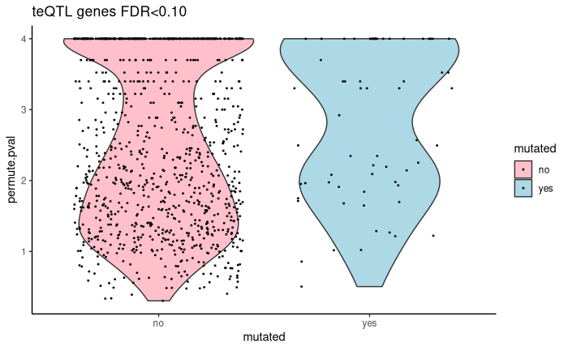

```r
library(ggplot2)
library(dplyr)
setwd('~/Documents/QTL/')
teqtl10.mutated.kozak <- read.table('teqtl.fdr10.mutated.kozak.table')
nonteqtl10.mutated.kozak <- read.table('non.teqtl.fdr10.mutated.kozak.table')
teqtl10.unmutated.kozak <- read.table('teqtl.fdr10.unmutated.kozak.table')
nonteqtl10.unmutated.kozak <- read.table('non.teqtl.fdr10.unmutated.kozak.table')
tablenames <- read.table('cis.teQTL.mapping.permutation.pass.results.table',nrows=1)
names(teqtl10.mutated.kozak) <- tablenames
names(nonteqtl10.mutated.kozak) <- tablenames
names(teqtl10.unmutated.kozak) <- tablenames
names(nonteqtl10.unmutated.kozak) <- tablenames
teqtl10.mutated.kozak$mutated <- 'yes'
nonteqtl10.mutated.kozak$mutated <- 'yes'
teqtl10.unmutated.kozak$mutated <- 'no'
nonteqtl10.unmutated.kozak$mutated <- 'no'
teqtl10.merged <- rbind(teqtl10.mutated.kozak[, c(1, 6, 7, 9)], teqtl10.unmutated.kozak[, c(1, 6, 7, 9)])
teqtl10.merged$permute.pval = -log10(teqtl10.merged$permute.pval)
teqtl10.merged$beta = -log10(abs(teqtl10.merged$beta))
nonteqtl10.merged <- rbind(nonteqtl10.mutated.kozak[, c(1, 6, 7 ,9)], nonteqtl10.unmutated.kozak[, c(1, 6 ,7 ,9)])
nonteqtl10.merged$permute.pval = -log10(nonteqtl10.merged$permute.pval)
nonteqtl10.merged$beta = -log10(abs(nonteqtl10.merged$beta))
teqtl10.merged %>%
  ggplot(aes(x = mutated, y = permute.pval, fill = mutated)) + geom_violin() + geom_jitter(color="black", size=0.4, alpha=0.9) + scale_fill_manual(values = c('pink', 'light blue')) + theme_classic() + ggtitle('teQTL genes FDR<0.10')
```

```r
wilcox.test(permute.pval ~ mutated, data = teqtl10.merged, exact = FALSE)
```

```
    Wilcoxon rank sum test with continuity correction

data:  permute.pval by mutated
W = 24850, p-value = 0.01506
alternative hypothesis: true location shift is not equal to 0
```

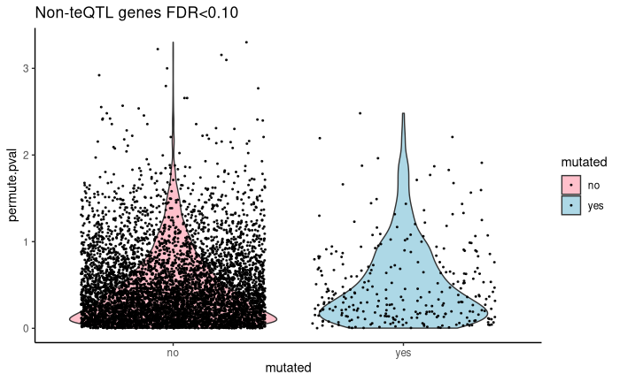

```r
nonteqtl10.merged %>%
  ggplot(aes(x = mutated, y = permute.pval, fill = mutated)) + geom_violin() + geom_jitter(color="black", size=0.4, alpha=0.9) + scale_fill_manual(values = c('pink', 'light blue')) + theme_classic() + ggtitle('Non-teQTL genes FDR<0.10')
```

```r
wilcox.test(permute.pval ~ mutated, data = nonteqtl10.merged, exact = FALSE)
```

```
    Wilcoxon rank sum test with continuity correction

data:  permute.pval by mutated
W = 880713, p-value = 0.3307
alternative hypothesis: true location shift is not equal to 0
```

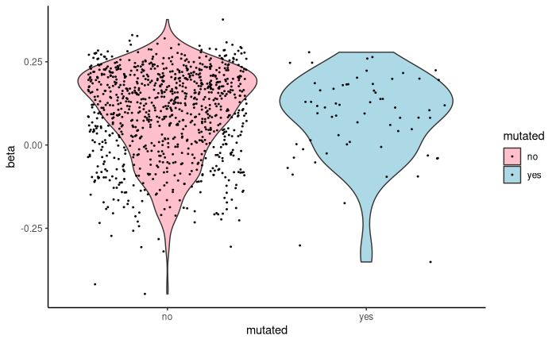

```r
teqtl10.merged %>%
  ggplot(aes(x = mutated, y = beta, fill = mutated)) + geom_violin() + geom_jitter(color="black", size=0.4, alpha=0.9) + scale_fill_manual(values = c('pink', 'light blue')) + theme_classic()
```

```r
wilcox.test(beta ~ mutated, data = teqtl10.merged, exact = FALSE)
```

```
    Wilcoxon rank sum test with continuity correction

data:  beta by mutated
W = 32573, p-value = 0.3157
alternative hypothesis: true location shift is not equal to 0
```

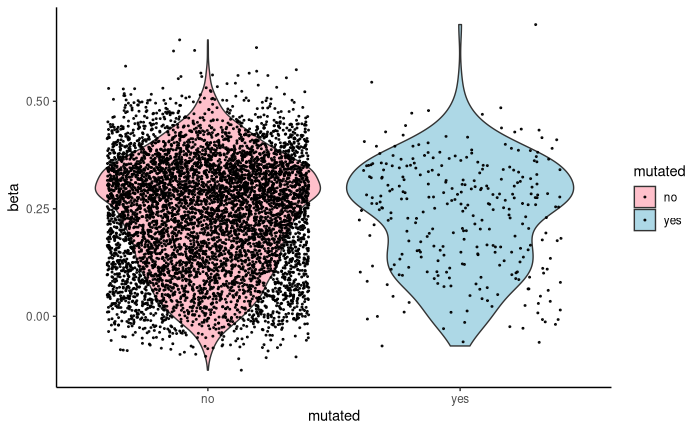

```r
nonteqtl10.merged %>%
  ggplot(aes(x = mutated, y = beta, fill = mutated)) + geom_violin() + geom_jitter(color="black", size=0.4, alpha=0.9) + scale_fill_manual(values = c('pink', 'light blue')) + theme_classic()
```

```r
wilcox.test(beta ~ mutated, data = nonteqtl10.merged, exact = FALSE)
```

```
    Wilcoxon rank sum test with continuity correction

data:  beta by mutated
W = 913381, p-value = 0.9503
alternative hypothesis: true location shift is not equal to 0
```

#Get gene ids for Kozak mutated genes  
awk ‘{print $5}’ results.teqtl.fdr05.table > teqtl.fdr05.mutated.kozak.names  
awk ‘{print $5}’ results.nonteqtl.fdr05.table > non.teqtl.fdr05.mutated.kozak.names  
#Select genes with mutated Kozak; caveat: some genes match to multiple SNPs in the Kozak region; total number of genes is less than matched SNPs  
grep -f teqtl.fdr05.mutated.kozak.names teqtl.fdr05.table > teqtl.fdr05.mutated.kozak.table  
grep -f non.teqtl.fdr05.mutated.kozak.names non.teqtl.fdr05.table > non.teqtl.fdr05.mutated.kozak.table  
#If want to include duplicate matches awk ‘NR==FNR{A[$1]=$0;next}{print A[$1]}’ teqtl.fdr05.table teqtl.fdr05.mutated.kozak.names > teqtl.fdr05.mutated.kozak.table.dupes  
awk ‘NR==FNR{A[$1]=$0;next}{print A[$1]}’ non.teqtl.fdr05.table non.teqtl.fdr05.mutated.kozak.names > non.teqtl.fdr05.mutated.kozak.table.dupes  
#Select genes with no mutated Kozak grep -vf teqtl.fdr05.mutated.kozak.names teqtl.fdr05.table > teqtl.fdr05.unmutated.kozak.table  
grep -vf non.teqtl.fdr05.mutated.kozak.names non.teqtl.fdr05.table > non.teqtl.fdr05.unmutated.kozak.table

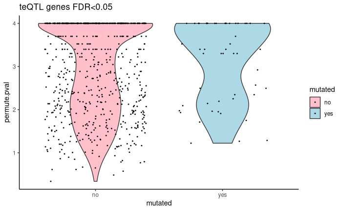

```r
library(ggplot2)
library(dplyr)
setwd('~/Documents/QTL/')
teqtl05.mutated.kozak <- read.table('teqtl.fdr05.mutated.kozak.table')
nonteqtl05.mutated.kozak <- read.table('non.teqtl.fdr05.mutated.kozak.table')
teqtl05.unmutated.kozak <- read.table('teqtl.fdr05.unmutated.kozak.table')
nonteqtl05.unmutated.kozak <- read.table('non.teqtl.fdr05.unmutated.kozak.table')
tablenames <- read.table('cis.teQTL.mapping.permutation.pass.results.table',nrows=1)
names(teqtl05.mutated.kozak) <- tablenames
names(nonteqtl05.mutated.kozak) <- tablenames
names(teqtl05.unmutated.kozak) <- tablenames
names(nonteqtl05.unmutated.kozak) <- tablenames
teqtl05.mutated.kozak$mutated <- 'yes'
nonteqtl05.mutated.kozak$mutated <- 'yes'
teqtl05.unmutated.kozak$mutated <- 'no'
nonteqtl05.unmutated.kozak$mutated <- 'no'
teqtl05.merged <- rbind(teqtl05.mutated.kozak[, c(1, 6, 7, 9)], teqtl05.unmutated.kozak[, c(1, 6, 7, 9)])
teqtl05.merged$permute.pval = -log10(teqtl05.merged$permute.pval)
teqtl05.merged$beta = -log10(abs(teqtl05.merged$beta))
nonteqtl05.merged <- rbind(nonteqtl05.mutated.kozak[, c(1, 6, 7 ,9)], nonteqtl05.unmutated.kozak[, c(1, 6 ,7 ,9)])
nonteqtl05.merged$permute.pval = -log10(nonteqtl05.merged$permute.pval)
nonteqtl05.merged$beta = -log10(abs(nonteqtl05.merged$beta))
teqtl05.merged %>%
  ggplot(aes(x = mutated, y = permute.pval, fill = mutated)) + geom_violin() + geom_jitter(color="black", size=0.4, alpha=0.9) + scale_fill_manual(values = c('pink', 'light blue')) + theme_classic() + ggtitle('teQTL genes FDR<0.05')
```

```r
wilcox.test(permute.pval ~ mutated, data = teqtl05.merged, exact = FALSE)
```

```
    Wilcoxon rank sum test with continuity correction

data:  permute.pval by mutated
W = 15292, p-value = 0.2292
alternative hypothesis: true location shift is not equal to 0
```

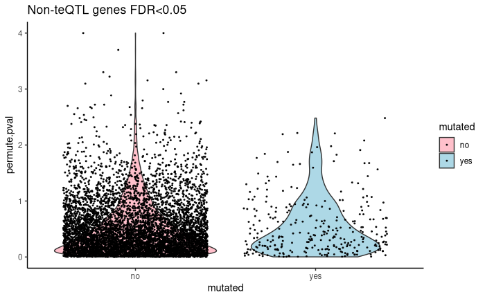

```r
nonteqtl05.merged %>%
  ggplot(aes(x = mutated, y = permute.pval, fill = mutated)) + geom_violin() + geom_jitter(color="black", size=0.4, alpha=0.9) + scale_fill_manual(values = c('pink', 'light blue')) + theme_classic() + ggtitle('Non-teQTL genes FDR<0.05')
```

```r
wilcox.test(permute.pval ~ mutated, data = nonteqtl05.merged, exact = FALSE)
```

```
    Wilcoxon rank sum test with continuity correction

data:  permute.pval by mutated
W = 964911, p-value = 0.3933
alternative hypothesis: true location shift is not equal to 0
```

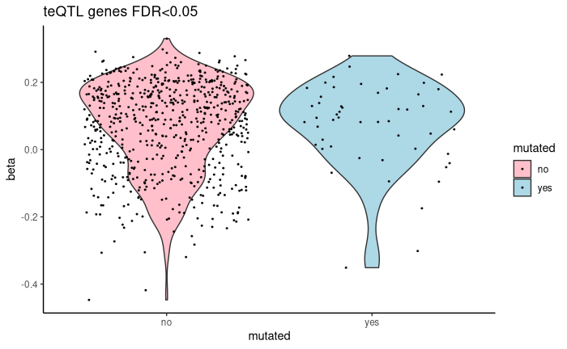

```r
teqtl05.merged %>%
  ggplot(aes(x = mutated, y = beta, fill = mutated)) + geom_violin() + geom_jitter(color="black", size=0.4, alpha=0.9) + scale_fill_manual(values = c('pink', 'light blue')) + theme_classic() + ggtitle('teQTL genes FDR<0.05')
```

```r
wilcox.test(beta ~ mutated, data = teqtl05.merged, exact = FALSE)
```

```
    Wilcoxon rank sum test with continuity correction

data:  beta by mutated
W = 16827, p-value = 0.9297
alternative hypothesis: true location shift is not equal to 0
```

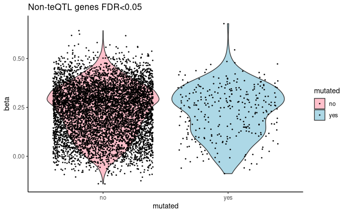

```r
nonteqtl05.merged %>%
  ggplot(aes(x = mutated, y = beta, fill = mutated)) + geom_violin() + geom_jitter(color="black", size=0.4, alpha=0.9) + scale_fill_manual(values = c('pink', 'light blue')) + theme_classic() + ggtitle('Non-teQTL genes FDR<0.05')
```

```r
wilcox.test(beta ~ mutated, data = nonteqtl05.merged, exact = FALSE)
```

```
    Wilcoxon rank sum test with continuity correction

data:  beta by mutated
W = 997892, p-value = 0.9008
alternative hypothesis: true location shift is not equal to 0
```

#Get gene ids for Kozak mutated genes  
awk ‘{print $5}’ results.teqtl.fdr01.table > teqtl.fdr01.mutated.kozak.names  
awk ‘{print $5}’ results.nonteqtl.fdr01.table > non.teqtl.fdr01.mutated.kozak.names  
#Select genes with mutated Kozak; caveat: some genes match to multiple SNPs in the Kozak region; total number of genes is less than matched SNPs  
grep -f teqtl.fdr01.mutated.kozak.names teqtl.fdr01.table > teqtl.fdr01.mutated.kozak.table  
grep -f non.teqtl.fdr01.mutated.kozak.names non.teqtl.fdr01.table > non.teqtl.fdr01.mutated.kozak.table  
#If want to include duplicate matches awk ‘NR==FNR{A[$1]=$0;next}{print A[$1]}’ teqtl.fdr01.table teqtl.fdr01.mutated.kozak.names > teqtl.fdr01.mutated.kozak.table.dupes  
awk ‘NR==FNR{A[$1]=$0;next}{print A[$1]}’ non.teqtl.fdr01.table non.teqtl.fdr01.mutated.kozak.names > non.teqtl.fdr01.mutated.kozak.table.dupes  
#Select genes with no mutated Kozak grep -vf teqtl.fdr01.mutated.kozak.names teqtl.fdr01.table > teqtl.fdr01.unmutated.kozak.table  
grep -vf non.teqtl.fdr01.mutated.kozak.names non.teqtl.fdr01.table > non.teqtl.fdr01.unmutated.kozak.table

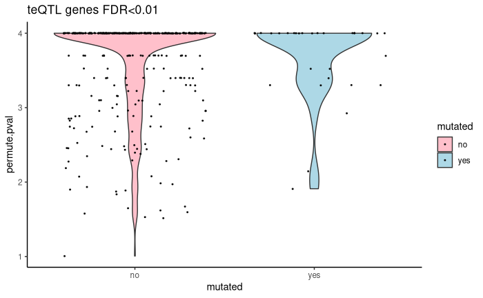

```r
library(ggplot2)
library(dplyr)
setwd('~/Documents/QTL/')
teqtl01.mutated.kozak <- read.table('teqtl.fdr01.mutated.kozak.table')
nonteqtl01.mutated.kozak <- read.table('non.teqtl.fdr01.mutated.kozak.table')
teqtl01.unmutated.kozak <- read.table('teqtl.fdr01.unmutated.kozak.table')
nonteqtl01.unmutated.kozak <- read.table('non.teqtl.fdr01.unmutated.kozak.table')
tablenames <- read.table('cis.teQTL.mapping.permutation.pass.results.table',nrows=1)
names(teqtl01.mutated.kozak) <- tablenames
names(nonteqtl01.mutated.kozak) <- tablenames
names(teqtl01.unmutated.kozak) <- tablenames
names(nonteqtl01.unmutated.kozak) <- tablenames
teqtl01.mutated.kozak$mutated <- 'yes'
nonteqtl01.mutated.kozak$mutated <- 'yes'
teqtl01.unmutated.kozak$mutated <- 'no'
nonteqtl01.unmutated.kozak$mutated <- 'no'
teqtl01.merged <- rbind(teqtl01.mutated.kozak[, c(1, 6, 7, 9)], teqtl01.unmutated.kozak[, c(1, 6, 7, 9)])
teqtl01.merged$permute.pval = -log10(teqtl01.merged$permute.pval)
teqtl01.merged$beta = -log10(abs(teqtl01.merged$beta))
nonteqtl01.merged <- rbind(nonteqtl01.mutated.kozak[, c(1, 6, 7 ,9)], nonteqtl01.unmutated.kozak[, c(1, 6 ,7 ,9)])
nonteqtl01.merged$permute.pval = -log10(nonteqtl01.merged$permute.pval)
nonteqtl01.merged$beta = -log10(abs(nonteqtl01.merged$beta))
teqtl01.merged %>%
  ggplot(aes(x = mutated, y = permute.pval, fill = mutated)) + geom_violin() + geom_jitter(color="black", size=0.4, alpha=0.9) + scale_fill_manual(values = c('pink', 'light blue')) + theme_classic() + ggtitle('teQTL genes FDR<0.01')
```

```r
wilcox.test(permute.pval ~ mutated, data = teqtl01.merged, exact = FALSE)
```

```
    Wilcoxon rank sum test with continuity correction

data:  permute.pval by mutated
W = 5154, p-value = 0.7218
alternative hypothesis: true location shift is not equal to 0
```

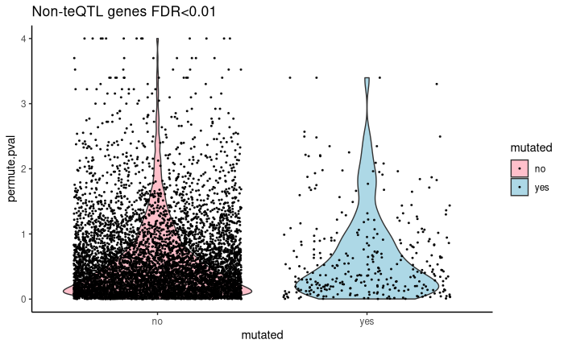

```r
nonteqtl01.merged %>%
  ggplot(aes(x = mutated, y = permute.pval, fill = mutated)) + geom_violin() + geom_jitter(color="black", size=0.4, alpha=0.9) + scale_fill_manual(values = c('pink', 'light blue')) + theme_classic() + ggtitle('Non-teQTL genes FDR<0.01')
```

```r
wilcox.test(permute.pval ~ mutated, data = nonteqtl01.merged, exact = FALSE)
```

```
    Wilcoxon rank sum test with continuity correction

data:  permute.pval by mutated
W = 1059226, p-value = 0.1449
alternative hypothesis: true location shift is not equal to 0
```

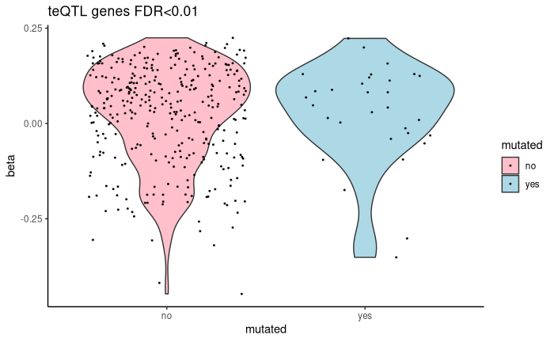

```r
teqtl01.merged %>%
  ggplot(aes(x = mutated, y = beta, fill = mutated)) + geom_violin() + geom_jitter(color="black", size=0.4, alpha=0.9) + scale_fill_manual(values = c('pink', 'light blue')) + theme_classic() + ggtitle('teQTL genes FDR<0.01')
```

```r
wilcox.test(beta ~ mutated, data = teqtl01.merged, exact = FALSE)
```

```
    Wilcoxon rank sum test with continuity correction

data:  beta by mutated
W = 5337, p-value = 0.9938
alternative hypothesis: true location shift is not equal to 0
```

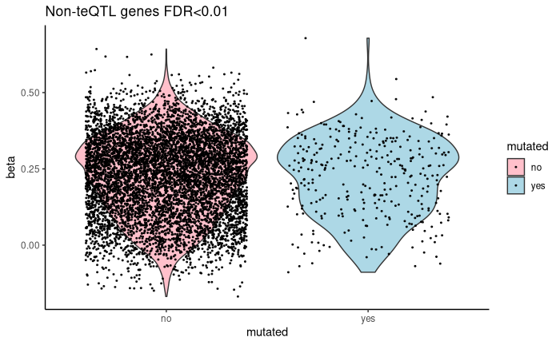

```r
nonteqtl01.merged %>%
  ggplot(aes(x = mutated, y = beta, fill = mutated)) + geom_violin() + geom_jitter(color="black", size=0.4, alpha=0.9) + scale_fill_manual(values = c('pink', 'light blue')) + theme_classic() + ggtitle('Non-teQTL genes FDR<0.01')
```

```r
wilcox.test(beta ~ mutated, data = nonteqtl01.merged, exact = FALSE)
```

```
    Wilcoxon rank sum test with continuity correction

data:  beta by mutated
W = 1123631, p-value = 0.7596
alternative hypothesis: true location shift is not equal to 0
```